# Project 1

Tien Le, Jackson Kelly

2024-10-17

# Introduction

Our study aims to better understand diabetes and predict it based on various individual characteristics. Diabetes is one of the most chronic, costly, and consequential diseases. By gaining a deeper understanding of diabetes and making accurate predictions, we can help in treatment and care for those affected. By examining different contributing factors to diabetes, such as BMI, age, and plasma glucose concentration, we can identify patterns in those affected and and make predictions about others based on these observations. We hope that the findings of our study can improve diagnosis by more accurately identifying diabetes in at risk individuals.

Diabetes is a serious issue that affects an estimated 8.5% of adults worldwide. It can cause heart attack, strokes, kidney failure, and death. For type 2 diabetes, which is the majority of cases, it is often preventable, and the worst effects can be avoided by an early diagnosis and treatment (“Diabetes — Who.int”). Therefore, being able to effectively diagnose diabetes is critical, and we hope our findings can help contribute to doing so.

# Data

Our data set comes from the National Institute of Diabetes and Digestive and Kidney Diseases. This data set examines 768 individuals, with measurements for their number of pregnancies, glucose level, blood pressure, skin thickness, insulin levels, BMI, age, and diabetes pedigree (a genetic estimate of an individual’s likelihood to develop diabetes). 268 of these individuals do have diabetes, and are labeled accordingly. This label is found in the outcome column and is binary, with a 1 signifying an individual with diabetes, and a 0 an individual without.

This data set has a lot of key information with regards to diabetes. For example, according the WHO, 95% of diabetes cases are type 2, which is often attributed to being overweight, not getting enough exercise, and genetics. Thus a measurement like BMI is very relevant to examining diabetes. Additionally, features like insulin and glucose level relate directly to the disease, and thus their measurement is important (“Diabetes — Who.int”). The limitation of the data set is that we are only looking at 8 features, and there are more factors that can potentially cause diabetes. The data set is also relatively small, with only 268 diabetic individuals potentially not properly illustrating true patterns. (“Diabetes Healthcare: Comprehensive Dataset-AI — Kaggle.com”)

# Analysis

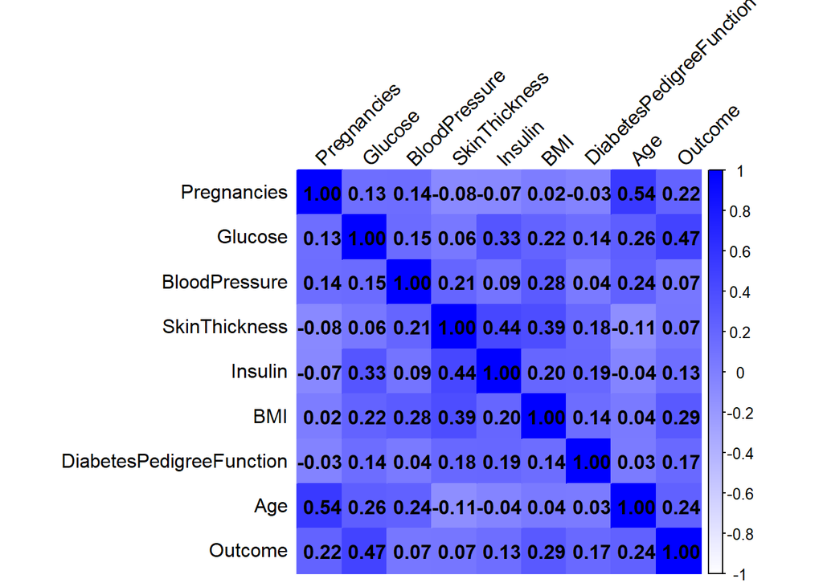

```r
data <- read.csv("health care diabetes.csv")
data <- na.omit(data)

library(corrplot)
matrix <- cor(data)

corrplot(matrix, method = "color", col = colorRampPalette(c("white", "blue"))(500), addCoef.col = "black", tl.srt = 45, tl.col = "black")
```

In this figure, we see the relationship of different attributes with each other, and ultimately with diabetes as a whole. This is done by calculating the correlation coefficient for each combination of attributes. Based on the bottom row, we can see that Glucose, BMI, and Age have the largest correlation with diabetes (at 0.47, 0.29, and 0.24 respectively). We also observe logical correlations in some of the attributes, such as number of pregnancies and age.

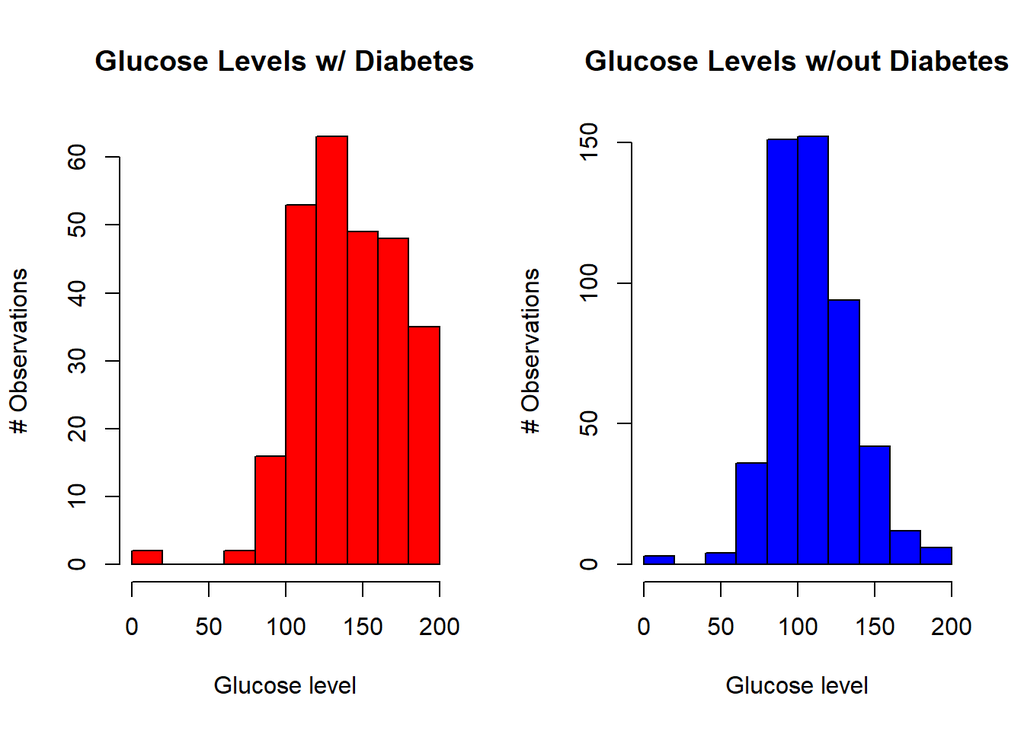

```r
par(mfrow = c(1, 2))
hist(data[data$Outcome == 1, ]$Glucose, xlab = 'Glucose level', ylab = '# Observations', main='Glucose Levels w/ Diabetes', xlim = c(min(data$Glucose), max(data$Glucose)), col = "red")
hist(data[data$Outcome == 0, ]$Glucose, xlab = 'Glucose level', ylab = '# Observations', main='Glucose Levels w/out Diabetes', xlim = c(min(data$Glucose), max(data$Glucose)), col = "blue")
```